# Freeze 5b Glycemic Traits

```r
data.dir <- "/Users/amanning/Documents/Manning_Lab_Dev/ANALYSIS-FI-FG-Freeze5b/"
in.d <- read.table(paste(data.dir,"/Pooled_Glycemic_Traits_freeze5b_duplicates_20171224.ped",sep=""),sep="\t",header=T)
```

```r
tapply(in.d$FastingGlucose, in.d$T2D_FG, summary)
```

```
$`1`
   Min. 1st Qu.  Median    Mean 3rd Qu.    Max.    NA's
  2.109   4.778   5.205   5.239   5.661   6.993    5184

$`2`
   Min. 1st Qu.  Median    Mean 3rd Qu.    Max.    NA's
     NA      NA      NA     NaN      NA      NA    2585
```

```r
tapply(in.d$FastingInsulin, in.d$T2D_FI, summary)
```

```
$`1`
    Min.  1st Qu.   Median     Mean  3rd Qu.     Max.     NA's
   0.000    7.952   17.400   27.090   35.000 2666.712     8401

$`2`
   Min. 1st Qu.  Median    Mean 3rd Qu.    Max.    NA's
     NA      NA      NA     NaN      NA      NA    2432
```

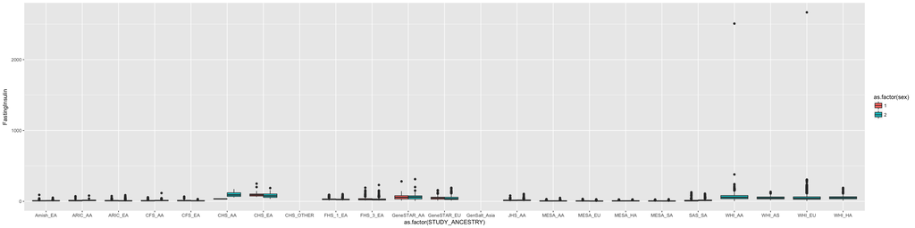

```r
library(ggplot2)
### http://www.sthda.com/english/wiki/ggplot2-density-plot-quick-start-guide-r-software-and-data-visualization
ggplot(in.d,aes(as.factor(STUDY_ANCESTRY),FastingInsulin,fill=as.factor(sex))) + geom_boxplot()
```

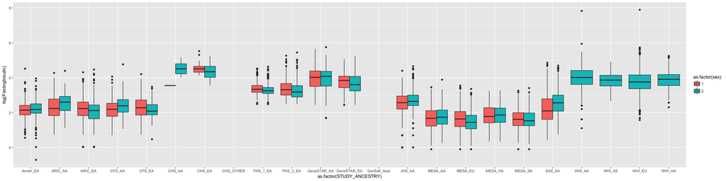

```r
ggplot(in.d,aes(as.factor(STUDY_ANCESTRY),log(FastingInsulin),fill=as.factor(sex))) + geom_boxplot()
```

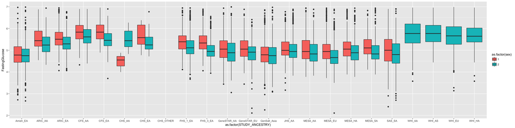

```r
library(ggplot2)
### http://www.sthda.com/english/wiki/ggplot2-density-plot-quick-start-guide-r-software-and-data-visualization
ggplot(in.d,aes(as.factor(STUDY_ANCESTRY),FastingGlucose,fill=as.factor(sex))) + geom_boxplot()
```

```r
logFIstats <- cbind(N=with(in.d, tapply(log(in.d$FastingInsulin), list("STUDY"=in.d$STUDY_ANCESTRY), function(x){sum(!is.na(x))})),
Min=with(in.d, tapply(log(in.d$FastingInsulin), list("STUDY"=in.d$STUDY_ANCESTRY), min,na.rm=T)),
Median=with(in.d, tapply(log(in.d$FastingInsulin), list("STUDY"=in.d$STUDY_ANCESTR), median,na.rm=T)),
Mean=with(in.d, tapply(log(in.d$FastingInsulin), list("STUDY"=in.d$STUDY_ANCESTRY), mean,na.rm=T)),
SD=with(in.d, tapply(log(in.d$FastingInsulin), list("STUDY"=in.d$STUDY_ANCESTRY), sd,na.rm=T)),
Max=with(in.d, tapply(log(in.d$FastingInsulin), list("STUDY"=in.d$STUDY_ANCESTRY), max,na.rm=T)))
```

```
no non-missing arguments to min; returning Infno non-missing arguments to min; returning Infno non-missing arguments to max; returning -Infno non-missing arguments to max; returning -Inf
```

```r
print(logFIstats,digits = 2)
```

```
                N    Min Median Mean   SD  Max
Amish_EA      902 -0.713    2.2  2.2 0.48  4.5
ARIC_AA       129  0.726    2.4  2.4 0.67  4.4
ARIC_EA      2232  0.033    2.1  2.1 0.64  4.5
CFS_AA        236  0.693    2.3  2.3 0.62  4.8
CFS_EA        188  0.470    2.2  2.2 0.57  4.2
CHS_AA         10  3.547    4.2  4.2 0.59  5.2
CHS_EA         51  3.547    4.4  4.4 0.40  5.5
CHS_OTHER       0    Inf     NA  NaN   NA -Inf
FHS_1_EA     1598  2.485    3.3  3.3 0.30  4.6
FHS_3_EA     1178  2.485    3.2  3.3 0.49  5.4
GeneSTAR_AA   261  1.686    4.1  3.9 0.66  5.7
GeneSTAR_EU   193  2.434    3.7  3.7 0.61  5.3
GenSalt_Asia    0    Inf     NA  NaN   NA -Inf
JHS_AA       2317  0.000    2.6  2.6 0.53  4.7
MESA_AA       822   -Inf    1.7 -Inf  NaN  3.9
MESA_EU      1593   -Inf    1.5 -Inf  NaN  3.5
MESA_HA       783  0.336    1.8  1.8 0.58  3.3
MESA_SA       481 -0.105    1.6  1.6 0.57  3.4
SAS_SA        930  0.405    2.4  2.4 0.79  4.9
WHI_AA        905  1.099    4.0  4.0 0.60  7.8
WHI_AS        103  2.667    3.9  3.9 0.44  4.9
WHI_EU       4388  1.569    3.8  3.8 0.59  7.9
WHI_HA        208  2.303    3.9  3.9 0.53  5.2
```

```r
FGstats <- cbind(N=with(in.d, tapply(in.d$FastingGlucose, list("STUDY"=in.d$STUDY_ANCESTRY), function(x){sum(!is.na(x))})),
Min=with(in.d, tapply(in.d$FastingGlucose, list("STUDY"=in.d$STUDY_ANCESTRY), min,na.rm=T)),
Median=with(in.d, tapply(in.d$FastingGlucose, list("STUDY"=in.d$STUDY_ANCESTR), median,na.rm=T)),
Mean=with(in.d, tapply(in.d$FastingGlucose, list("STUDY"=in.d$STUDY_ANCESTRY), mean,na.rm=T)),
SD=with(in.d, tapply(in.d$FastingGlucose, list("STUDY"=in.d$STUDY_ANCESTRY), sd,na.rm=T)),
Max=with(in.d, tapply(in.d$FastingGlucose, list("STUDY"=in.d$STUDY_ANCESTRY), max,na.rm=T)))
```

```
no non-missing arguments to min; returning Infno non-missing arguments to max; returning -Inf
```

```r
print(FGstats,digits = 2)
```

```
                N Min Median Mean   SD  Max
Amish_EA      910 2.7    4.8  4.8 0.58  7.0
ARIC_AA       124 4.3    5.3  5.4 0.53  6.9
ARIC_EA      2197 4.1    5.4  5.4 0.45  6.9
CFS_AA        236 4.3    5.7  5.7 0.52  6.9
CFS_EA        191 3.7    5.6  5.7 0.51  7.0
CHS_AA         10 4.0    5.2  5.2 0.70  6.3
CHS_EA         52 4.7    5.3  5.5 0.50  6.8
CHS_OTHER       0 Inf     NA  NaN   NA -Inf
FHS_1_EA     1639 3.7    5.2  5.3 0.53  6.9
FHS_3_EA     1277 3.9    5.1  5.2 0.47  6.9
GeneSTAR_AA   592 3.1    4.9  5.0 0.63  7.0
GeneSTAR_EU   788 2.1    5.0  5.0 0.55  6.9
GenSalt_Asia 1650 2.3    4.8  4.8 0.58  7.0
JHS_AA       2326 3.2    4.9  5.0 0.50  6.9
MESA_AA       822 3.8    4.9  5.0 0.59  6.9
MESA_EU      1592 2.1    4.8  4.8 0.54  6.9
MESA_HA       782 3.8    5.0  5.0 0.58  6.9
MESA_SA       481 3.9    4.9  5.1 0.57  6.9
SAS_SA        930 2.4    4.9  4.9 0.75  6.9
WHI_AA        918 3.6    5.8  5.8 0.58  7.0
WHI_AS        112 4.4    5.8  5.8 0.55  7.0
WHI_EU       4731 3.1    5.7  5.7 0.56  7.0
WHI_HA        212 3.6    5.6  5.7 0.56  7.0
```

in.d$logFastingInsulin <- log(in.d$FastingInsulin)

pooled.traits <- in.d[,c(“Individual_ID”,“Family_ID”,“Mother_ID”,“Father_ID”,“sex”,“T2D”,“STUDY_ANCESTRY”,“age_FI”,“T2D_FI”,“BMI_FI”,“FastingInsulin”,“logFastingInsulin”,“FastingGlucose”)] cohort.traits <- in.d[,c(“Individual_ID”,“Family_ID”,“Mother_ID”,“Father_ID”,“sex”,“T2D”,“STUDY_ANCESTRY”,“age_FI”, “T2D_FI”,“BMI_FI”,“FastingInsulin”,“logFastingInsulin”,“FastingGlucose”)]

pooled.traits$logFastingInsulin_adj <- NA pooled.traits$logFastingInsulin_adj_invn <- NA

in.d.cases.FI <- !in.d$T2D_FI %in% c(0,1) in.d.cases.FG <- !in.d$T2D_FI %in% c(0,1)

in.d.females <- in.d$sex==2 table(in.d.females)

sink(“make.residuals.txt”)

cohorts <- names(table(in.d$STUDY_ANCESTRY)) for(cohort in cohorts) { print(paste(“COHORT:”,cohort))

```
in.d[which(in.d$STUDY_ANCESTRY==cohort),]

print(paste("FASTING INSULIN"))
tmp.FI <- make.residuals.transform("logFastingInsulin","age_FI+BMI_FI",
                                in.d[which(in.d$STUDY_ANCESTRY==cohort),],
                                casesTF=in.d.cases.FI[which(in.d$STUDY_ANCESTRY==cohort)],
                                femaleTF=in.d.females[which(in.d$STUDY_ANCESTRY==cohort)])

pooled.traits$logFastingInsulin_adj[which(in.d$STUDY_ANCESTRY==cohort)] <- tmp.FI[,"logFastingInsulin_adj_by_sex"]
pooled.traits$logFastingInsulin_adj_invn[which(in.d$STUDY_ANCESTRY==cohort)] <- tmp.FI[,"logFastingInsulin_adj_invn"]

print(paste("FASTING GLUCOSE"))

tmp.FG <- make.residuals.transform("FastingGlucose","age_FG+BMI_FG",
                                in.d[which(in.d$STUDY_ANCESTRY==cohort),],
                                casesTF=in.d.cases.FG[which(in.d$STUDY_ANCESTRY==cohort)],
                                femaleTF=in.d.females[which(in.d$STUDY_ANCESTRY==cohort)])

pooled.traits$FastingGlucose_adj[which(in.d$STUDY_ANCESTRY==cohort)] <- tmp.FG[,"FastingGlucose_adj_by_sex"]
pooled.traits$FastingGlucose_adj_invn[which(in.d$STUDY_ANCESTRY==cohort)] <- tmp.FG[,"FastingGlucose_adj_invn"]


tmp.cohort.traits.FI <- cbind(logFastingInsulin_adj=rep(NA,nrow(pooled.traits)),
                            logFastingInsulin_adj_invn=rep(NA,nrow(pooled.traits)))

tmp.cohort.traits.FI[which(in.d$STUDY_ANCESTRY==cohort),"logFastingInsulin_adj"] <- tmp.FI[,"logFastingInsulin_adj_by_sex"]
tmp.cohort.traits.FI[which(in.d$STUDY_ANCESTRY==cohort),"logFastingInsulin_adj_invn"] <- tmp.FI[,"logFastingInsulin_adj_invn"]
colnames(tmp.cohort.traits.FI) <- paste(colnames(tmp.cohort.traits.FI),"_",cohort,sep="")

tmp.cohort.traits.FG <- cbind(FastingGlucose_adj=rep(NA,nrow(pooled.traits)),
                            FastingGlucose_adj_invn=rep(NA,nrow(pooled.traits)))

tmp.cohort.traits.FG[which(in.d$STUDY_ANCESTRY==cohort),"FastingGlucose_adj"] <- tmp.FG[,"FastingGlucose_adj_by_sex"]
tmp.cohort.traits.FG[which(in.d$STUDY_ANCESTRY==cohort),"FastingGlucose_adj_invn"] <- tmp.FG[,"FastingGlucose_adj_invn"]
colnames(tmp.cohort.traits.FG) <- paste(colnames(tmp.cohort.traits.FG),"_",cohort,sep="")


cohort.traits <- cbind(cohort.traits,tmp.cohort.traits.FI,tmp.cohort.traits.FG)
```

} sink()

write.table(pooled.traits,“pooled.traits.tsv”,col.names=T,row.names=F,sep=“”) write.table(cohort.traits,“cohort.traits.tsv”,col.names=T,row.names=F,sep=“”)

pdf(“residuals.pdf”,width=10,height=6); ggplot(pooled.traits,aes(as.factor(sex),logFastingInsulin)) + geom_boxplot() ggplot(pooled.traits,aes(as.factor(sex),logFastingInsulin_adj)) + geom_boxplot() ggplot(pooled.traits,aes(as.factor(sex),logFastingInsulin_adj_invn)) + geom_boxplot()

ggplot(pooled.traits,aes(x=logFastingInsulin,color=as.factor(sex))) + geom_density() + facet_grid(STUDY_ANCESTRY ~ .) ggplot(pooled.traits,aes(x=logFastingInsulin_adj,color=as.factor(sex))) + geom_density() + facet_grid(STUDY_ANCESTRY ~ .) ggplot(pooled.traits,aes(x=logFastingInsulin_adj_invn,color=as.factor(sex))) + geom_density() + facet_grid(STUDY_ANCESTRY ~ .)

ggplot(pooled.traits,aes(as.factor(sex),FastingGlucose)) + geom_boxplot() ggplot(pooled.traits,aes(as.factor(sex),FastingGlucose_adj)) + geom_boxplot() ggplot(pooled.traits,aes(as.factor(sex),FastingGlucose_adj_invn)) + geom_boxplot()

ggplot(pooled.traits,aes(x=FastingGlucose,color=as.factor(sex))) + geom_density() + facet_grid(STUDY_ANCESTRY ~ .) ggplot(pooled.traits,aes(x=FastingGlucose_adj,color=as.factor(sex))) + geom_density() + facet_grid(STUDY_ANCESTRY ~ .) ggplot(pooled.traits,aes(x=FastingGlucose_adj_invn,color=as.factor(sex))) + geom_density() + facet_grid(STUDY_ANCESTRY ~ .)

dev.off()